# Olist

#### Categorical columns

```r
cat <- c('payment_type', 'seller_city', 'product_category_name_english', 'seller_state', 'product', 'order_status', 'customer_city', 'customer_state')
catcols<-as_tibble(cat)
catcols
```

| value |
| --- |
| payment_type |
| seller_city |
| product_category_name_english |
| seller_state |
| product |
| order_status |
| customer_city |
| customer_state |

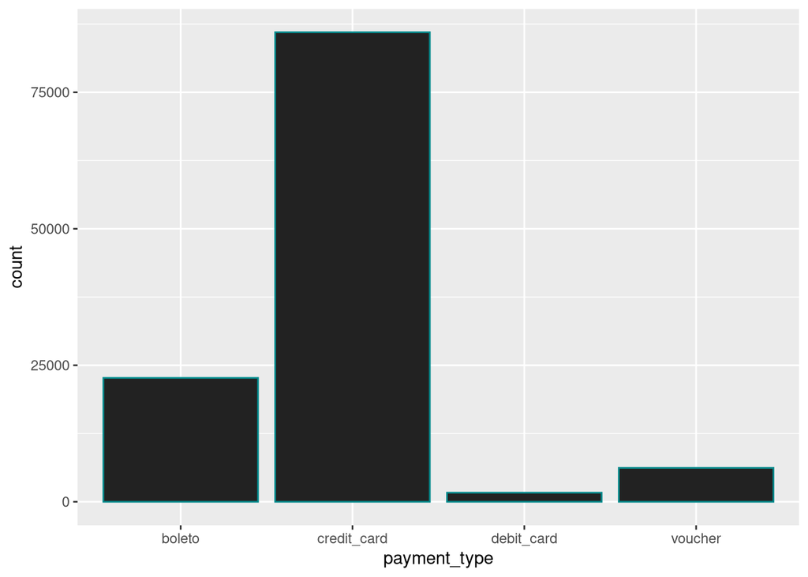

```r
ggplot(olist,aes(payment_type))+ geom_bar(fill='#222222', colour = "#038b8d")
```

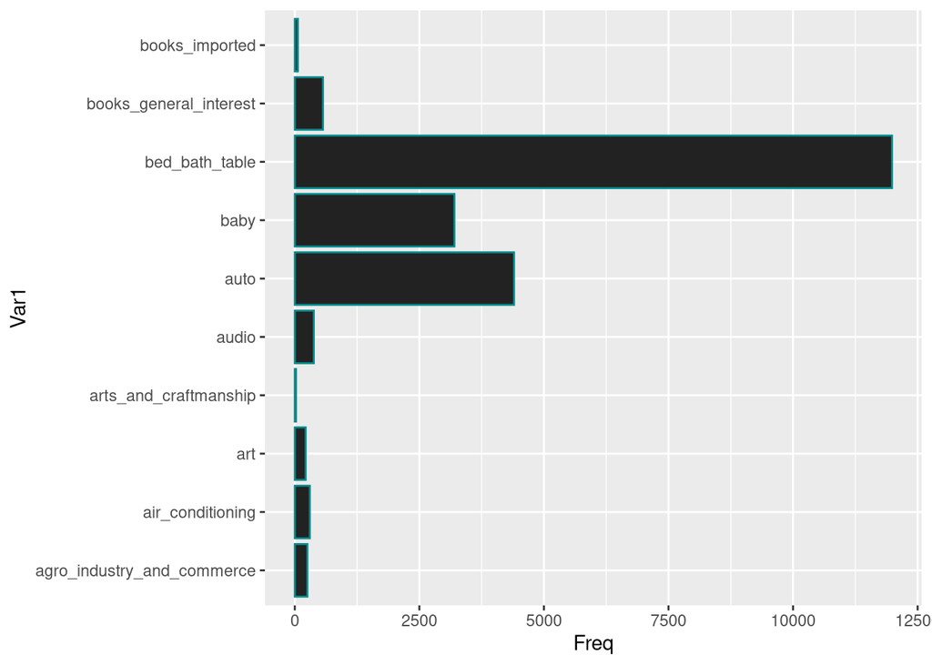

```r
pd_english <- table(olist$product_category_name_english)
pd_english <- as.data.frame(head(pd_english,10))
ggplot(pd_english,aes(x = Var1, y = Freq))+geom_bar(stat = "identity",fill='#222222', colour = "#038b8d")+coord_flip()
```

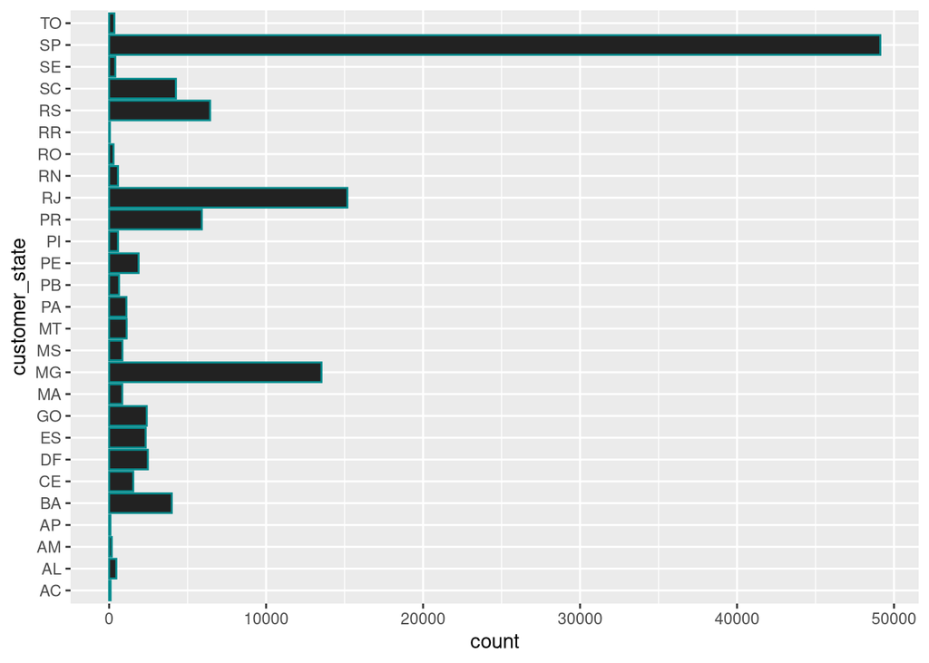

```r
ggplot(olist,aes(customer_state))+ geom_bar(fill='#222222', colour = "#038b8d")+coord_flip()
```

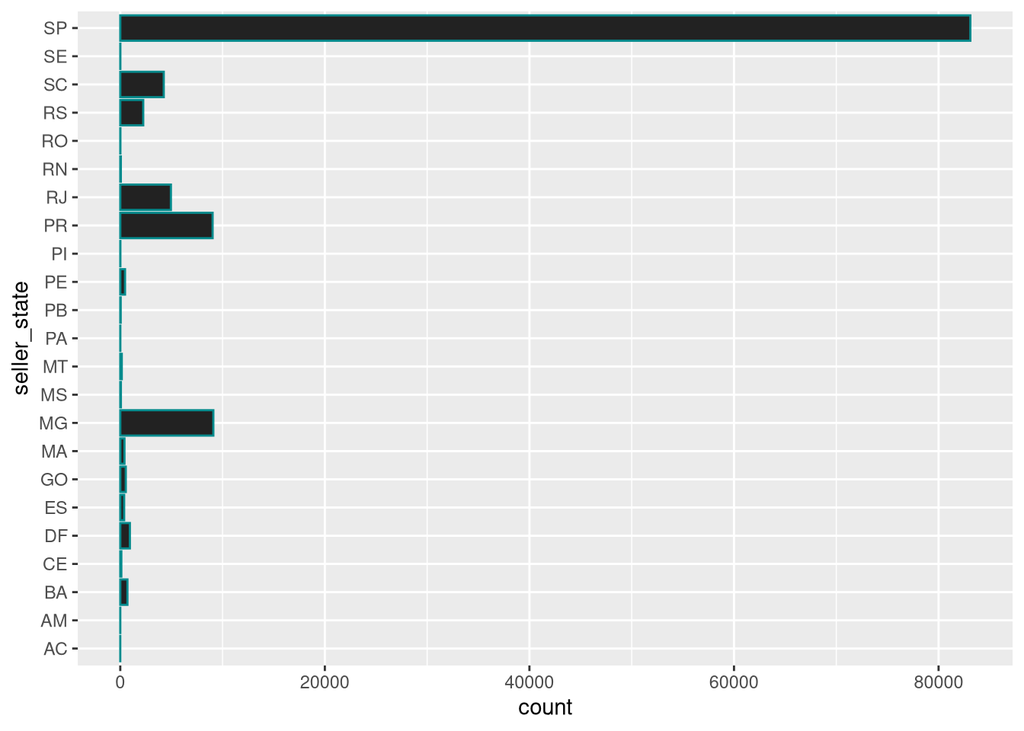

```r
ggplot(olist,aes(seller_state))+ geom_bar(fill='#222222', colour = "#038b8d")+coord_flip()
```

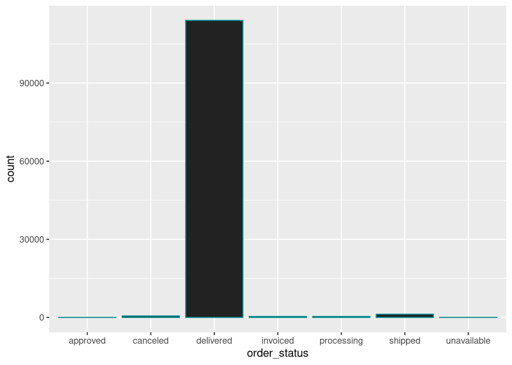

```r
ggplot(olist,aes(order_status))+ geom_bar(fill='#222222', colour = "#038b8d")
```

### Bivariate Analysis

```r
# plot(olist$review_score, olist$price, xlab="review_score", ylab="price")
```

review score is not highly affected by the price of the products. high priced tend to have a 5 score rating.

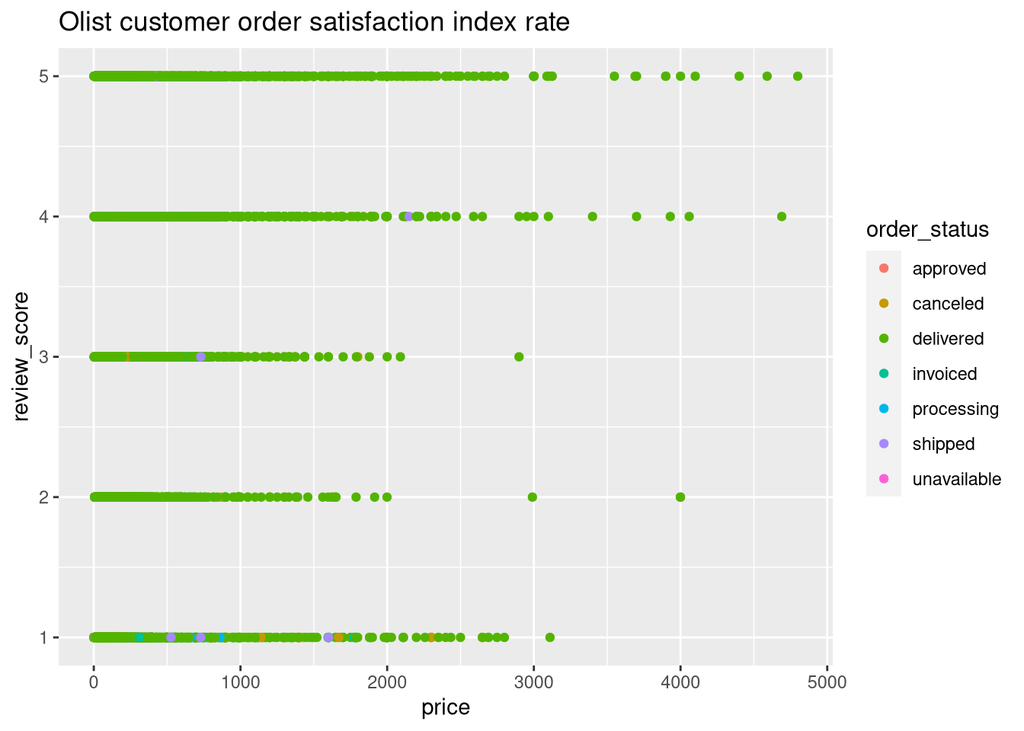

```r
ggplot(olist, aes(x=price, y = review_score )) + geom_point(aes(colour= `order_status`))+
         labs(title='Olist customer order satisfaction index rate')
```

- Most Olist orders are fulfilled and delivered. few orders are not delivered and most customers have 5/4 star rated whether expensive or cheap.

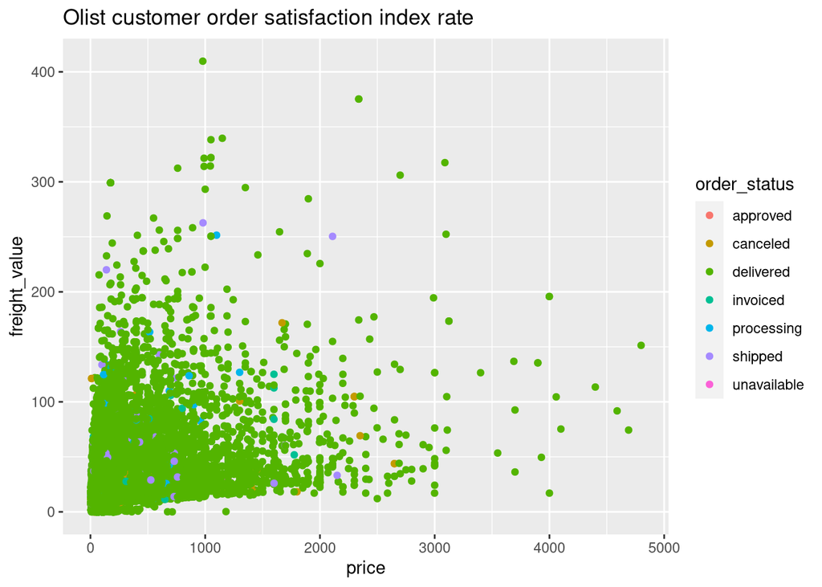

```r
ggplot(olist, aes(x=price, y = freight_value )) + geom_point(aes(colour= `order_status`))+
        labs(title='Olist customer order satisfaction index rate')
```

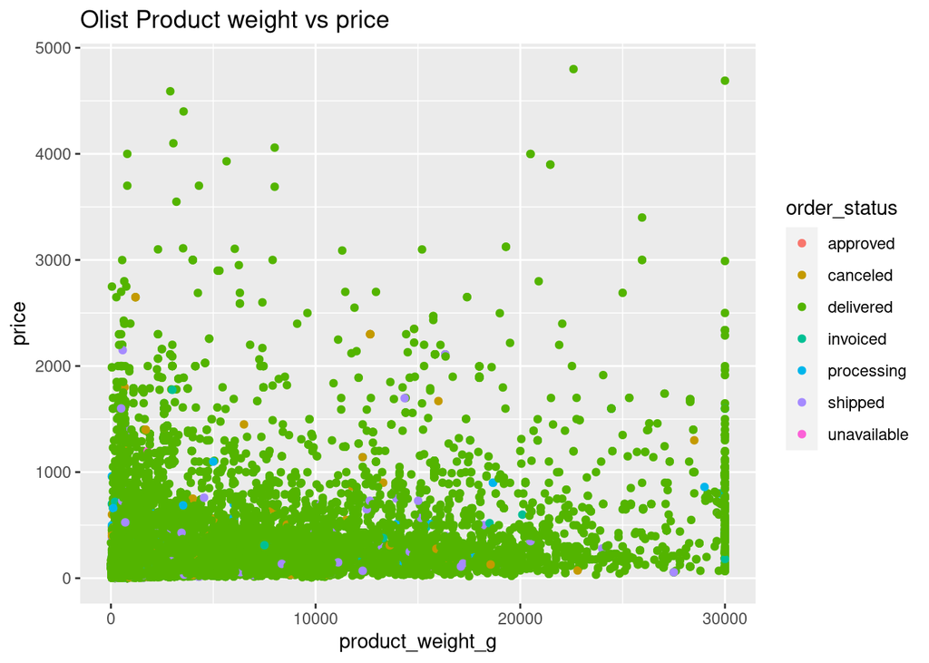

```r
ggplot(olist, aes(x=product_weight_g,
                            y = price )) + geom_point(aes(colour= `order_status`))+labs(title='Olist Product weight vs price')
```

The price of a product is not dependent on weight.

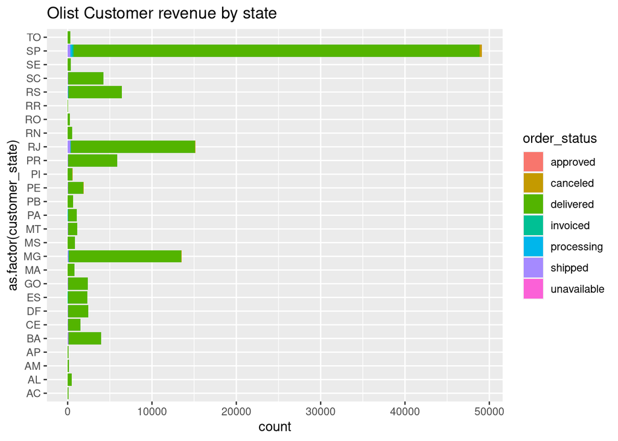

```r
ggplot(olist, aes(x=as.factor(customer_state))) + geom_bar(aes(fill= `order_status`)) +
        labs(title='Olist Customer revenue by state') + coord_flip()
```

- Most of the orders have been delivered to the Sao Paulo (SP), Rio de jeniero (RJ), MINAS GERIAS (MG).These where most of the customers are based but they need to concentrate more on other states with low delivered orders.

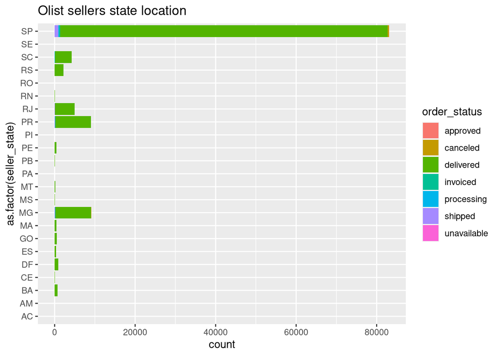

```r
ggplot(olist, aes(x=as.factor(seller_state))) + geom_bar(aes(fill= `order_status`)) +
        labs(title='Olist sellers state location') + coord_flip()
```

- Most of Olist sellers are located in Sao Paulo (SP), Minas Gerias (MG) and Parana (PR).

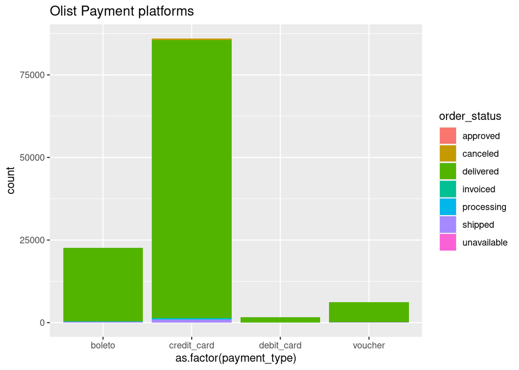

```r
ggplot(olist, aes(x=as.factor(payment_type))) + geom_bar(aes(fill= `order_status`)) +
        labs(title='Olist Payment platforms')
```

- most commonly used payment channel is credit card followed by boleto, which is one of the most popular online/offline payment methods in Brazil that allows you to pay for Skype Credit and subscriptions.

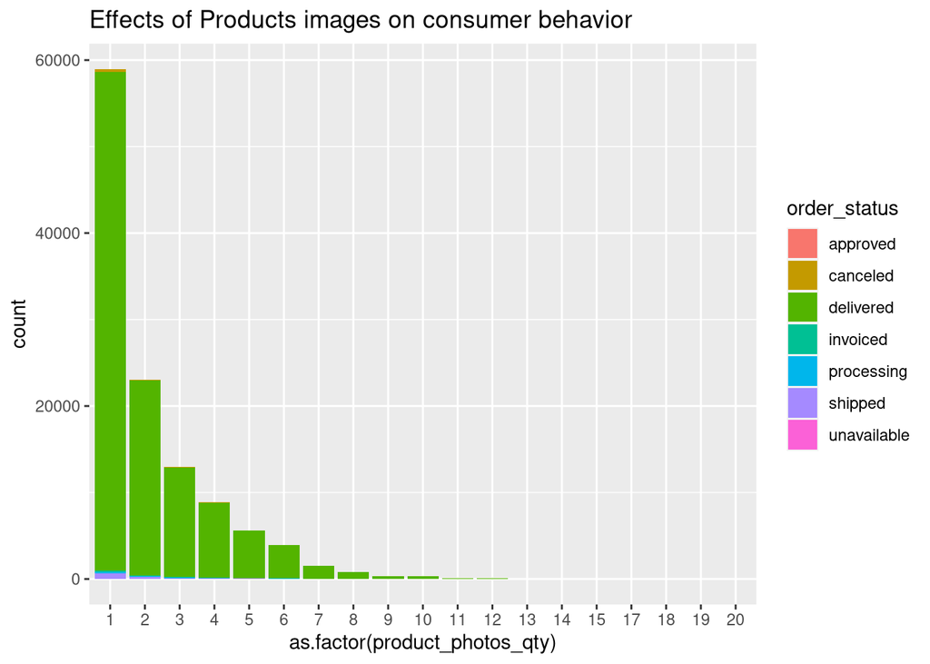

```r
ggplot(olist, aes(x=as.factor(product_photos_qty))) + geom_bar(aes(fill= `order_status`)) + labs(title='Effects of Products images on consumer behavior')
```

- Less the photos more the orders.

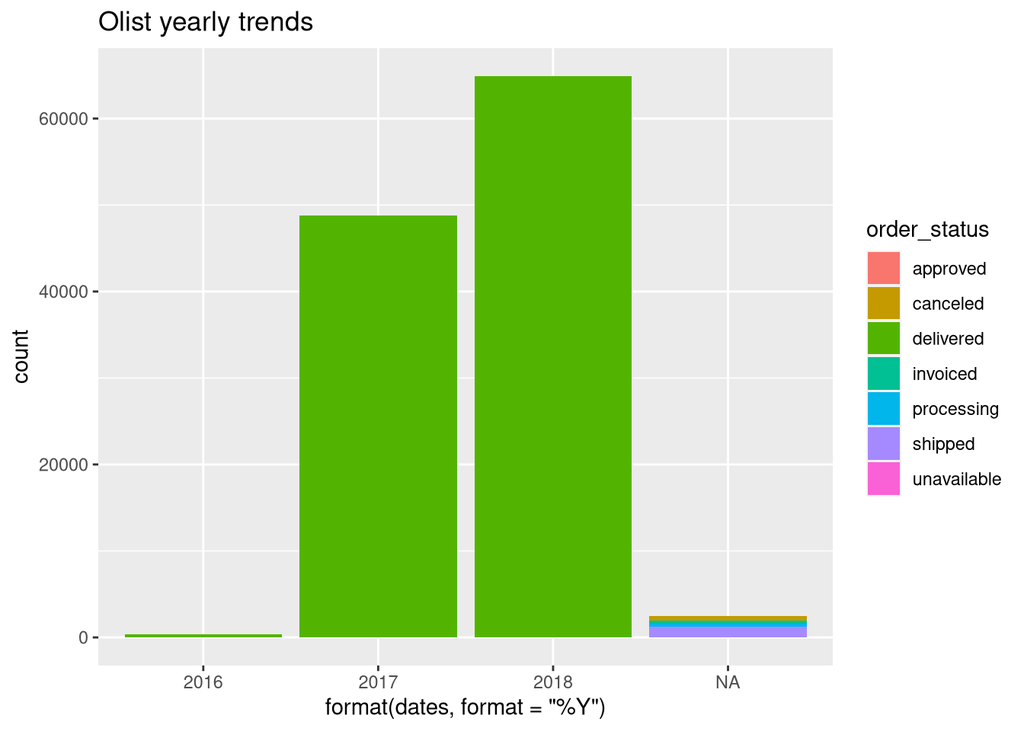

```r
dates <- olist$order_delivered_customer_date
ggplot(olist, aes(format(dates, format = "%Y"))) + geom_bar(aes(fill= `order_status`)) + labs(title='Olist yearly trends')
```

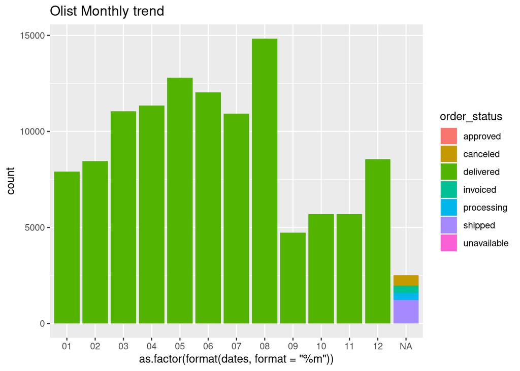

```r
ggplot(olist, aes(x=as.factor(format(dates, format = "%m")))) +geom_bar(aes(fill= `order_status`))+
        labs(title='Olist Monthly trend')
```

- The highest revenue recorded in the second quarter of the year most of the purchases this due to state and public holidays below;
1. APRIL 20 sao paulo state
2. BRIDGE HOLIDAY in Brazil
3. LABOUR DAY -MAY 1ST-Brazil
4. JUL 09 SAO PAULO STATE REBELLION DAY-sao paulo
5. AUG 09-FATHERS DAY- Brazil
6. SEP 07 -NATIONAL INDEPENDENCE DAY- Brazil

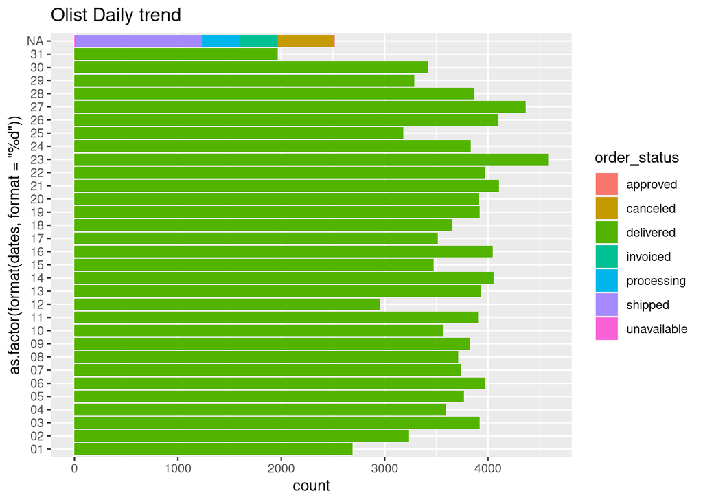

```r
ggplot(olist, aes(x=as.factor(format(dates, format = "%d")))) + geom_bar(aes(fill= `order_status`)) + labs(title='Olist Daily trend') + coord_flip()
```

- Sales are equally distributed within the days of the month.

```r
#Checking the correlation of variables
# library('corrplot')
# library('ggcorrplot')
get_lower_tri<-function(cor_mat){
    cor_mat[upper.tri(cor_mat)] <- NA
    return(cor_mat)
}
corr <- round(cor(select_if(num.col, is.numeric)), 2)
# lower <- get_lower_tri(corr)
melted <- melt(corr, na.rm = TRUE)
head(melted)
```

|  | X1 | X2 | value |
| --- | --- | --- | --- |
| 1 | customer_zip_code_prefix | customer_zip_code_prefix | 1.00 |
| 2 | order_item_id | customer_zip_code_prefix | 0.00 |
| 3 | price | customer_zip_code_prefix | 0.04 |
| 4 | freight_value | customer_zip_code_prefix | 0.23 |
| 5 | payment_sequential | customer_zip_code_prefix | -0.02 |
| 6 | payment_installments | customer_zip_code_prefix | 0.06 |

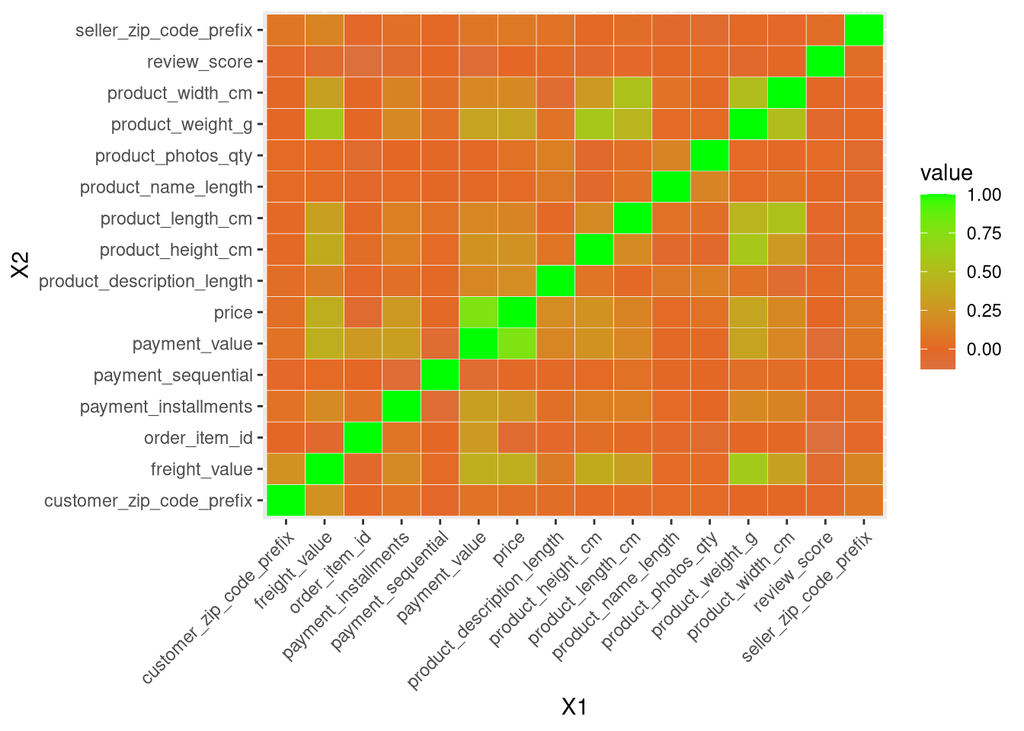

```r
ggplot(melted, aes(X1, X2))+  geom_tile(aes(fill = value), colour = "white") +
  scale_fill_gradient2(low = "#6D9EC1", high = "green", mid = "#E46726")+
  theme(axis.text.x = element_text(angle = 45, hjust = 1))
```

```r
# ggcorrplot(corr, hc.order = T, ggtheme = ggplot2::theme_gray,
#    colors = c("#6D9EC1", "green", "#E46726"), lab = T)+
#   theme(axis.text.x = element_text(angle = 45, hjust = 1))
```